# Guia para instalação do Code::Blocks

Author

Affiliation

Diogo Silva

Academia da Força Aérea

O Code::Blocks é um ambiente de desenvolvimento simples para C e C++. Durante o processo de instalação podem ocorrer alguns problemas de configuração. A forma mais simples de usar o Code::Blocks é através do procedimento que se segue.

1. Visitar o [website do Code::Blocks](https://www.codeblocks.org/)
2. Ir até à página `Downloads`.
3. Clicar em `Download the binary release`
4. Fazer o download da versão `codeblocks-20.03mingw-nosetup.zip`.

**Note**

A versão que tem `mingw` inclui já o compilador necessário para o desenvolvimento de software em C. A versão `nosetup` não precisa de permissões de administrador nem de instalação no computador. É um simples ficheiro comprimido (.zip).

5. Extrair o conteúdo do ficheiro comprimido.
6. Navegar a pasta com o conteúdo extraído até encontrar o executável do Code::Blocks. Executar o Code::Blocks.
7. Configurar compilador:
   1. É provável receber um alerta sobre a ausência de compilador configurado.
   2. Ir ao menu `Settings` > `Compiler` > `Toolchain executables` > `Auto-detect` > `OK`

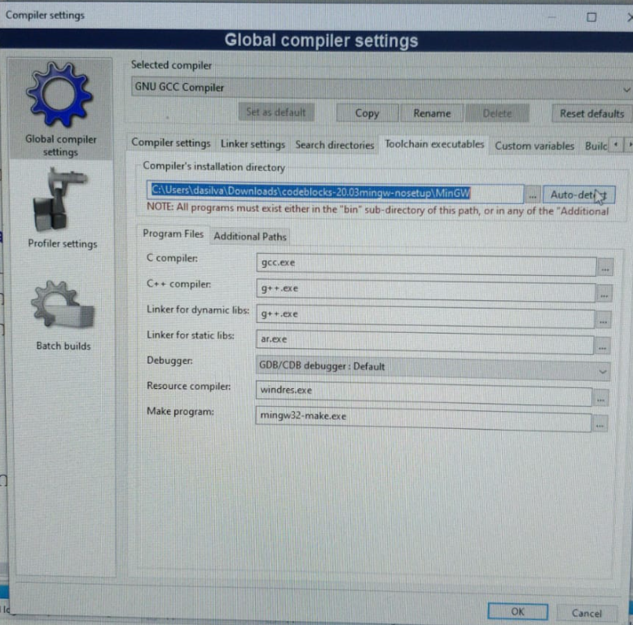

   3. O caminho para o compilador (`MinGW`) deverá ter sido correctamente detectado e configurado.
8. Testar com um projecto (a partir daqui, podem seguir as instruções antigas, que têm screenshots de cada passo).
   1. Ir ao menu `File` > `New` > `Project`
   2. Na janela seguinte escolher `Console application`
   3. Na escolha de linguagem, escolher `C` (e não `C++`)
   4. Na janela seguinte, escolher um nome para o projecto (`Project title`) e uma pasta onde o guardar (`Folder to create project in`).
   5. Na janela seguinte, selecionar ambos `Create "Debug" configuration` e `Create "Release" configuration`, e clicar em `Finish`.
   6. Ir até ao menu `Build` > `Build and run` (ou pressionar a tecla `F9`). O programa deverá ter compilado e executado com sucesso.
9. Para continuar a programar, na janela à esquerda na tab `Projects`, abrir `Workspace` > Nome do projecto > `Sources` > `main.c`. O ficheiro de código deverá abrir e ficar disponível para edição.